# HAB data Exploration

Badhia Yunes Katz

August 2025

This report is has an overview of harmful algal bloom (HAB) data and practice in the Klamath Basin (southern Oregon & northern California). It covers:

- What HAB parameters matter and the thresholds used in health guidance (with links to sources)
- What data exists in the Water Quality Portal (WQX) for the basin
- Data pull those data for the last ~10 years, flag likely HAB events, and map them
- Caveats for interpreting results

# 2. Basin context

The Klamath system includes Upper Klamath Lake, the Klamath River, and major tributaries. HABs occur as:

- Planktonic blooms (e.g., Microcystis) → often produce microcystins (toxin)
- Benthic cyanobacterial mats (e.g., Microcoleus) → can produce anatoxin-a, especially in river reaches

**Resources**  
- [Oregon Health Authority (OHA) HAB program (advisories, criteria, program logic)](https://www.oregon.gov/oha/PH/HEALTHYENVIRONMENTS/RECREATION/HARMFULALGAEBLOOMS/Pages/index.aspx) - [USGS Klamath studies overview](https://www.usgs.gov/centers/oregon-water-science-center/science/upper-klamath-basin-studies-and-data-collection)

# 3. HAB parameters (thresholds & sources)

These are the most decision-relevant parameters for recreational waters. We use them to classify toxic events and bloom evidence.

[output not shown]

Benthic vs planktonic: In the Klamath River, benthic mats can drive anatoxin-a even when the water column seems clear—plan monitoring accordingly (see e.g., Genzoli et al., 2024, Freshwater Science).

# 4. What data is available

- **Water Quality Portal (WQX/NWIS/STORET):** In-situ measurements reported by agencies/tribes/utilities. We will pull the 7 parameters above for the Klamath Basin. https://www.waterqualitydata.us/
- **OHA HAB advisories (issue/lift dates):** Official public-health decisions for Oregon waters. https://www.oregon.gov/oha/PH/HEALTHYENVIRONMENTS/RECREATION/HARMFULALGAEBLOOMS/Pages/Blue-GreenAlgaeAdvisories.aspx
- **KBMP (Klamath Basin Monitoring Program) Blue-Green Algae Tracker:** Reach-level flags where thresholds are exceeded; useful spatial context. https://kbmp.net/maps-and-data
- **CyAN (EPA/NOAA/USGS) satellite index:** Weekly cyanobacteria index for large waters (e.g., Upper Klamath Lake). Public viewer: https://experience.arcgis.com/experience/01f798892ecb48d8ac99ef9b4ebe37c8

This markdown focuses on pulling data from WQX.

# 5. Toxic “events”

- **Toxic HAB event (primary evidence):** any sample with **Microcystin ≥ 8 µg/L** (or other cyanotoxin ≥ its threshold).
- **Bloom evidence (supporting):** **Cyanobacteria ≥ 100,000 cells/mL**, **Chlorophyll-a ≥ 30 µg/L** (screening), or **Phycocyanin ≥ 90th percentile** locally.
- **Interpretation tip:** If toxins are absent but **benthic mats** are present, consider **anatoxin-a** detection and site context.

# 6. Pulling WQX data (last ~10 years for Klamath Basin (HUC2 = 180102))

The workflow:

1. Query WQP for relevant parameters
2. Summarize maximum values per year and site
3. Identify likely bloom events
4. Map bloom locations and provide a summary table

```
##          date monitoring_location_identifier        monitoring_location_name.y
## 1  2021-08-11                YUROKTEP_WQX-WE Klamath River above Trinity River
## 2  2021-09-15               YUROKTEP_WQX-LES             Lower Estuary Surface
## 3  2021-09-15                YUROKTEP_WQX-TG      Klamath River at Turwar Gage
## 4  2021-08-11                YUROKTEP_WQX-WE Klamath River above Trinity River
## 5  2021-10-19      YUROKTEP_WQX-KR above WTP                      KR above WTP
## 6  2021-10-27                YUROKTEP_WQX-TG      Klamath River at Turwar Gage
## 7  2021-10-26                YUROKTEP_WQX-TG      Klamath River at Turwar Gage
## 8  2021-10-19      YUROKTEP_WQX-KR below WTP                      KR below WTP
## 9  2022-11-30      YUROKTEP_WQX-KR above WTP                      KR above WTP
## 10 2022-09-13                YUROKTEP_WQX-SS                      South Slough
##    characteristic_name value_num result_measure_measure_unit_code
## 1          Phycocyanin     0.522                              RFU
## 2          Phycocyanin     0.950                              RFU
## 3          Phycocyanin     0.459                              RFU
```

[output cut: 18 more lines]

Yearly context: per-site maxima

```
## # A tibble: 10 × 7
##    monitoring_location_identi…¹ monitoring_location_…² characteristic_name  year
##    <chr>                        <chr>                  <chr>               <dbl>
##  1 USGS-422305121553800         MID-TRENCH - LOWER   … Cyanobacteria        2014
##  2 USGS-422622122004000         MID-NORTH - LOWER  - … Cyanobacteria        2014
##  3 YUROKTEP_WQX-LES             Lower Estuary Surface  Chlorophyll a        2021
##  4 HVTEPA_WQX-KR_STREST_CDR     CDR and Nutrients at … Chlorophyll a        2018
##  5 USGS-421935121551200         UPPER KLAMATH LAKE AT… Chlorophyll a        2021
##  6 HVTEPA_WQX-KR_STREST_CDR     CDR and Nutrients at … Chlorophyll a        2019
##  7 HVTEPA_WQX-KR_STREST_CDR     CDR and Nutrients at … Chlorophyll a        2021
##  8 KLAMATHTRIBES_WQX-KL0009     UPPER KLAMATH LAKE AT… Chlorophyll a        2017
##  9 HVTEPA_WQX-TR_CAMPGRD        Fecal Coliform, Macro… Chlorophyll a        2021
## 10 USGS-422444121580400         SHOALWATER BAY - SHB   Chlorophyll a        2020
## # ℹ abbreviated names: ¹monitoring_location_identifier,
## #   ²monitoring_location_name.y
## # ℹ 3 more variables: samples <int>, max_value <dbl>, units <chr>
```

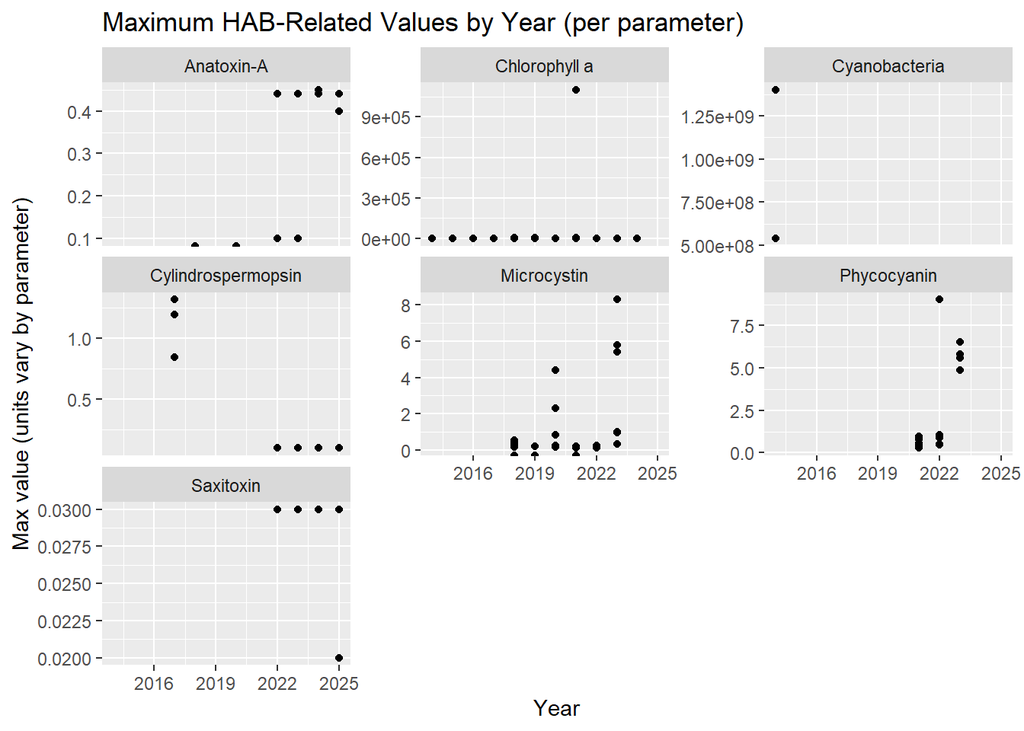

[interactive chart not shown]